# Examining Contributions Made to New England’s Democratic and Republican Candidates Running for Senate in the 2012 Elections

GroupMP2E: Nukhbah Majid, Chhiring Lama, Joyce Huang

3/22/2019

```r
##new_cand just filters for the candidates we want
filter_cand <- candidates %>%
  filter(cand_party_affiliation == "DEM" | cand_party_affiliation == "REP", cand_election_yr == "2012")

new_cand <- filter_cand %>%
  inner_join(contributions, by = "cand_id") %>%
  filter(transaction_type == "24A" | transaction_type == "24E", transaction_pgi == "G" | transaction_pgi == "G2012", cand_office == "S")
```

```r
new_cand$transaction_pgi <- revalue(new_cand$transaction_pgi, c("G2012" = "G"))
```

```r
# The plyr package was used to rename "G2012" to "G" to make the data consistent.
# Upon inspection, we found that plyr messes with the following data manipulation,
# that's why we detached it was detached after use.

detach(package:plyr)
```

```r
some_states <- c("CT", "MA", "RI")
some_df <- data.frame(some_states)

#call function on the names
new_data <- function(state_arg) {
  new_cand %>%
    filter(cand_office_state == state_arg) %>%
    group_by(transaction_type, cand_name, cand_office_state,
             cand_party_affiliation) %>%
    summarize(total = sum(transaction_amt)) %>%
    arrange(desc(total))
}

#map dataframe of states to the function
all_states <- map_df(some_df$some_states, new_data)
```

Our group decided to look at the Senate elections in 2012 for **Massachusetts (MA)**, **Rhode Island (RI)** and **Connecticut (CT)**. We initially wanted to look at all five states in *New England*, but *New Hampshire* did not have a Senate election. Furthermore, in **Vermont (VT)** and **Maine (ME)**, *Independent* candidates won - [*Bernie Sanders (VT)*](https://en.wikipedia.org/wiki/2012_United_States_Senate_election_in_Vermont) and [*Angus King (ME)*](https://en.wikipedia.org/wiki/2012_United_States_Senate_election_in_Maine) - and therefore are not relevant to the trend we are hoping to observe which is strictly applicable to **Democratic** and **Republican** affiliated candidates. Hence we only filtered the New England states that had Republican or Democratic candidates (CT, MA, RI) elected to Senate. This is because elections are typically polarized between Democrats and Republicans, and New England has a reputation of being a Democratic-dominant region, hence we wanted to compare candidates from these two parties.

We wanted to see how much independent expenditures committees spent for or against each candidate in each state. According to the [FEC](https://www.fec.gov/help-candidates-and-committees/making-independent-expenditures/), “Independent expenditures are not contributions and are not subject to limits.” For example, the money can be used for advertisements that identify or advocates/opposes a candidate, but the committee cannot collaborate with the candidate.

### More about the data graphic:

- The data graphic has the following attributes:
- It is a **bar** graph. We chose to plot a bar graph as it is more appropriate for plotting a categorical, qualitative variable (the different candidates belonging to Democratic and Republican parties) against a continuous, quantitative variable (the monetary independent expenditures (for/against) candidates by committees).
- The **axes**: the x-axis shows the candidates of Democratic and Republican parties, and the y-axis represents the monetary independent expenditures made by committees to these candidates in **millions** of dollars.
- The **bar color**: the color of the bar represents the party affiliation (**red** for Republicans, and **blue** for Democrats).
- The **label on top of the bars**: this is the accurate y-value (the amount of independent expenditures contributed to the candidates by the committees). These labels were important because some of the candidates have very low values of contributions made to them: e.g. the independent expenditures contributed to `Sheldon Whitehouse` to support his candidacy is very little in magnitude.
- The **color of the outline of the bars**: this represents the **type** of independent expenditures contributed by the committees to the particular candidate in question: **black** outline indicates the sum of money spent by all committees to **oppose** the candidate’s candidacy, and the **purple** outline indicates the sum of money spent by all committees to **support** the candidate’s candidacy. The **thickness** of the outline does **NOT** signify any factor - it’s set to a certain thickness just to make the color apparent.
- The **facet wrap**: differentiates the pairs of Democratic and Republican candidates by their office states - the three New England states we filtered for: CT, MA, and RI.
- (**Note**: The names were rotated 90 degrees because they overlapped with each other. The colors for the outlines were used so that there’s an apparent contrast with the background).

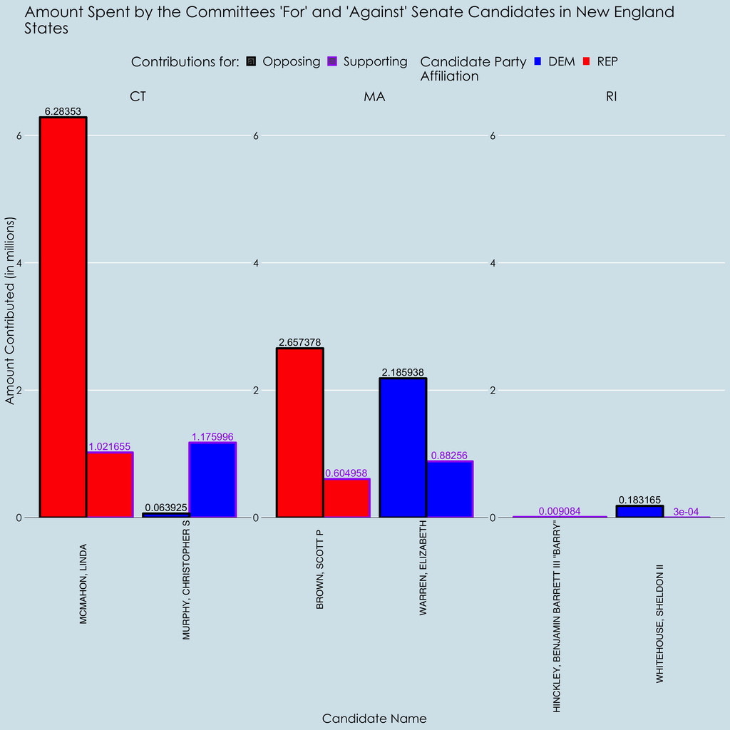

```r
fill_c <- c("black", "purple")
fill_party <- c("blue", "red")

##transaction amount in millions of dollars
ggplot(all_states, aes(x = cand_name, y = total/1000000, fill = cand_party_affiliation, color = transaction_type)) +
  geom_bar(stat = "identity", position = "dodge", size = 2) +
  scale_fill_manual("Candidate Party\nAffiliation",values = fill_party) +
  scale_color_manual("Contributions for:",labels = c("Opposing", "Supporting"), values = fill_c) +
  facet_wrap(~as.factor(cand_office_state), scales = "free") +
  scale_y_continuous(limits = c(0, 6.5), expand = c(0,0)) +
  geom_text(aes(label= total/1000000), position = position_dodge(width=0.9),
            vjust= -0.35, size = 7) +
  theme_economist() +
  theme(axis.text.x = element_text(angle = 90, hjust = 0.4, size = 18),
        axis.title.x = element_text(family = "Century Gothic",
                                    color = "black", face = "bold", size = 24),
        axis.text.y = element_text(family = "Century Gothic",
                                    color = "black", face = "bold", size = 20),
        axis.title.y = element_text(family = "Century Gothic",
                                    color = "black", face = "bold", size = 24),
        plot.title = element_text(family = "Century Gothic",
                                    color = "black", face = "bold", size = 30),
        strip.text = element_text(family = "Century Gothic", face = "bold", size = 26),
        legend.text = element_text(family = "Century Gothic", face = "bold", size = 24),
        legend.title = element_text(family = "Century Gothic", face = "bold", size = 26)) +
  labs(title = "Amount Spent by the Committees 'For' and 'Against' Senate Candidates in New England\nStates\n", x = "Candidate Name", y = "Amount Contributed (in millions)")
```

This data graphic shows the total contribution made ‘for’ and ‘against’ a candidate in the general senate election in MA, RI, and CT in 2012. In Connecticut, Chris Murphy [won](https://www.nytimes.com/elections/2012/results/senate.html) the election. The amount that committees spent supporting him was slightly more than his opponent, Linda McMahon; committees also spent more money against McMahon than Murphy. In Massachusetts, Elizabeth Warren won the election. The amount that committees spent advocating her election is greater than her opponent and incumbent for the state of MA, Scott P. Brown; the amount spent opposing her election is less than her opponent. In CT and MA, we observe that for the candidates who won, independent expenditures supporting them are higher and those against are lower than their opponents. Winners in both states are Democrats.

In Rhode Island is an interesting exception: Sheldon Whitehouse, a Democrat, won the election. However, independent expenditures spent opposing him is significantly higher than his opponent, Barry Hinckley. Hinckley also had more independent expenditures supporting him than Whitehouse. We think that Whitehouse won despite independent expenditures against him is because he is an [incumbent](https://ballotpedia.org/Sheldon_Whitehouse) candidate who has been serving RI since 2007. Our data graphic doesn’t show contributions such as loan endorsements or individual [donations](https://transition.fec.gov/pages/brochures/citizens.shtml#contribution). Whitehouse raised significantly more money overall for his [campaign](https://www.opensecrets.org/races/summary?cycle=2012&id=RIS1).

**Parting speculation:** This shows that although committees can raise large amounts of money supporting or opposing a candidate, their independent expenditures may not be enough to help the candidate win the election.

For further reference (and to reward us points for using the issues tab), check our GitHub repository.[^1]

> Word count: 781
[^1]: Link to github repository: https://github.com/jmeihuang/sds192-mp2-1.git